# Final Project

AnnMarie McAlinney

November 25, 2017

*Source file* ⇒ FinalProject.Rmd

For my final project I used data on sleep from the National Sleep Foundation. The data set looked at several variables including age, sleepiness in certain situations, hours people sleep and caffine intake. People ages 13 to 65 were surveyed, but I chose to focus on students so I looked at people ages 13 to 22 and wanted to see if there were any correlations in students’ sleeping habits. For several of the questions a variable with a value of 97 or higher is filtered out. This is because if a person answered with “I don’t know” it was recorded as 97 and for this analysis I only wanted to include data for those who could give an accurate value.

```r
#input data
Data_Sleep <- read.csv(file="Data_Sleep.csv")
print(Data_Sleep)
```

[output not shown]

[output cut: 9772 more lines]

### Are Students’ Sleeping Patterns Different in the Week vs. the Weekend?

First I compared the amount of hours students sleep at night during the week versus the weekend. The first chart looks at average time slept during the week by each age (13 - 22). It is then broken up by gender with 1 representing male and 2 representing female. While each age sleeps between 7 and 9 hours in the week, both the boys and girls sleep a little less in their mid to late teens. The second graph is set up identical to the first graph except it looks at the hours slept on the weekend. On the weekend students tend to only sleep about an extra hour more. The boys in their mid to late teens remained the ones to sleep the least however girls who are late teens into early twenties slept the least on the weekend.

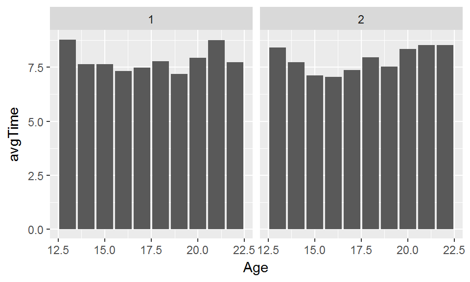

```r
#Create data set for the time slept during the week
#filter the data and group accordingly
Time_Slept_Week <-
Data_Sleep %>%
  filter(Age <= 22, Hours_Slept_Week < 97) %>%
  group_by(Age, Gender) %>%
  summarise(avgTime = mean(Hours_Slept_Week, na.rm=TRUE))

#Build the graph
 ggplot(data=Time_Slept_Week,aes(x=Age,y=avgTime ))+
  geom_bar(stat='identity',position='stack', width=.9)+
  facet_wrap(~Gender,ncol=3)
```

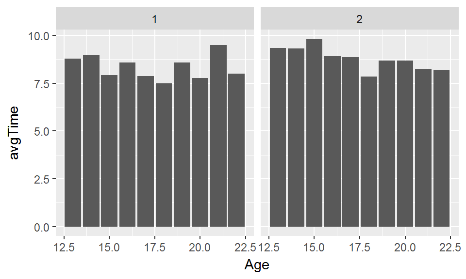

```r
#Create data slept for average time slept on the weekend
Time_Slept_Weekend <-
Data_Sleep %>%
  filter (Age <= 22) %>%
  group_by(Age, Gender) %>%
  summarise(avgTime = mean(HRS_Stud_Sleep_Weekend, na.rm=TRUE))

#Build Chart
ggplot(data=Time_Slept_Weekend,aes(x=Age,y=avgTime ))+
  geom_bar(stat='identity',position='stack', width=.9)+
  facet_wrap(~Gender,ncol=3)
```

### Do Caffinated Drinks Affect How Many Hours Students Sleep?

In this chart I was looking to see if there is a correlation between the amount of caffine consumed and the amount of hours students sleep. I thought there would be a very strong correlation and the more caffine one drank the less would they sleep. However, according to the data there was little correlation. Some students drank 0 drinks and barely slept while others drank 0 drinks and slept a lot.

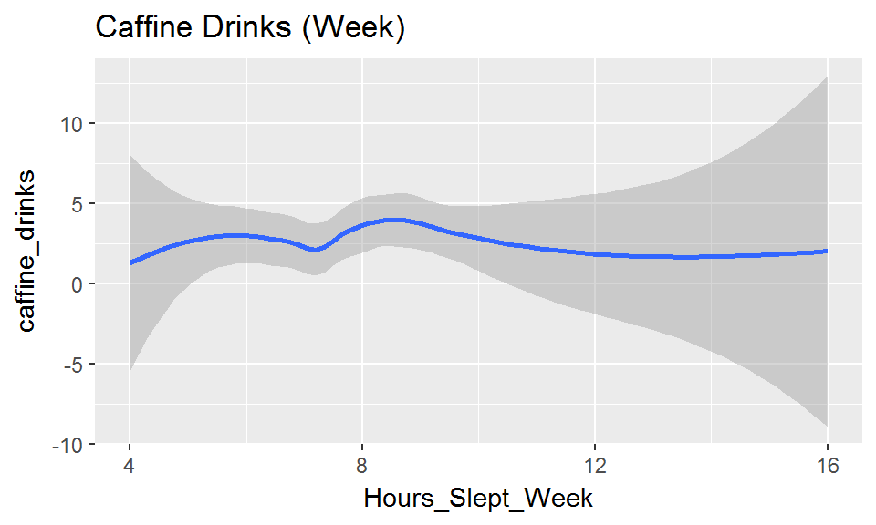

```r
#Create data table
#Q14TOTAL represents total caffine cups per day for each student
Caffine_Drinks <-
Data_Sleep %>%
  filter (Age <= 22, Q14TOTAL < 97, Hours_Slept_Week < 97) %>%
  group_by(Age, Hours_Slept_Week) %>%
  summarise(caffine_drinks = mean(Q14TOTAL, na.rm=TRUE))

#Build Plot
Caffine_Drinks %>%
  ggplot(aes(x=Hours_Slept_Week, y=caffine_drinks)) +
  geom_smooth(aes(color=Hours_Slept_Week)) +
  ggtitle("Caffine Drinks (Week)")
```

### Are students less sleepy in school if they sleep more at night?

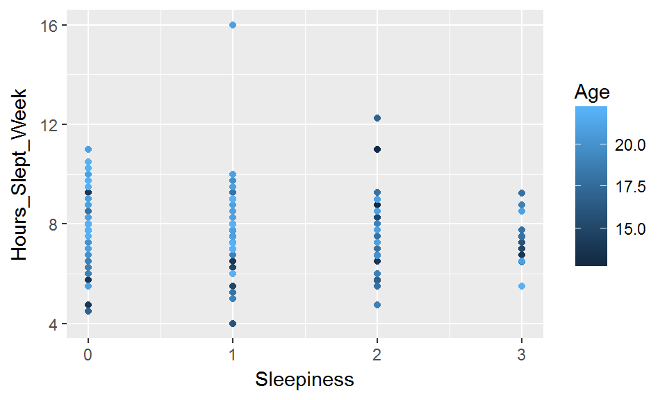

```r
#Create data table
#q15c represents the sleepiness variable
Sleepiness <-
  Data_Sleep %>%
  filter(Age <= 22) %>%
  filter(Hours_Slept_Week < 97) %>%
  group_by(Age, q15c, Hours_Slept_Week) %>%
  summarise(Sleepiness = mean(q15c, na.rm = TRUE))
#Create plot
ggplot(data=Sleepiness,aes(x=Sleepiness,y=Hours_Slept_Week))+
  geom_point()+
  aes(colour=Age)
```

### Do students sleep less when they use a cellphone right before bed?

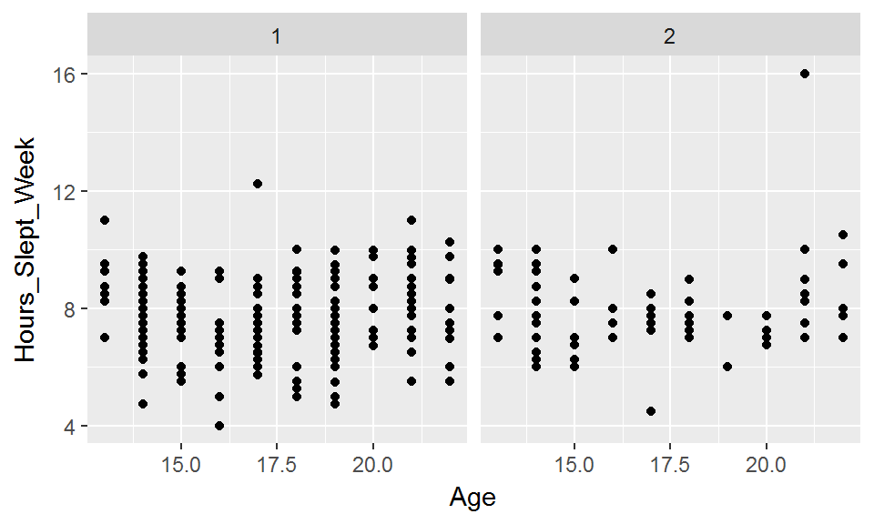

```r
#Create data table
#q19c represents cell phone use variable
Cellphone_Use <-
Data_Sleep %>%
  filter (Age <= 22, q19c < 97, Hours_Slept_Week <97) %>%
  group_by(Age, q19c, Hours_Slept_Week) %>%
  summarise(cellphone = mean(q19c, na.rm=TRUE))
#Create plot
ggplot(data=Cellphone_Use,aes(x=Age,y=Hours_Slept_Week))+
  geom_point()+
  facet_wrap(~cellphone,ncol=4)
```

### Conclusion

In conclusion there was more randomness in the sleep patterns of students then I was expecting. I was most suprised that the amount of hours students sleep did not affect how tired they were in school as much as people probably think. I think there must be a lot more outside factors that affect students’ sleep such as activities, amount of homework etc. Overall this data set was very interesting to analzye and provided some very interesting insight into the sleep habits of students.